# Hakai Institute Juvenile Salmon Report

Brett Johnson

Mon Jan 16 19:29:57 2023

The analysis uses Hill Numbers 0, 1, 2. Which are unified measures of species richness and Diversity. 0 is Species (stock) richness, 1 is Shannon Diversity, 2 is Simpsons Diversity.

[iNEXT R package user guide](http://chao.stat.nthu.edu.tw/wordpress/wp-content/uploads/software/iNEXT_UserGuide.pdf)

Chao, A., Gotelli, N.J., Hsieh, T.C., Sander, E.L., Ma, K.H., Colwell, R.K. & Ellison, A.M. (2014) Rarefaction and extrapolation with Hill numbers: a framework for sampling and estimation in species diversity studies. Ecological Monographs, 84, 45–67.

# 1 Compare Discovery Islands Channels

## 1.1 All years combined

When comparing migration corridors across all years there does not appear to be a significant difference in species richness, however Shannon and Simpson diversity appears to be higher in the Central corridor compared to East and West (Figure 1).

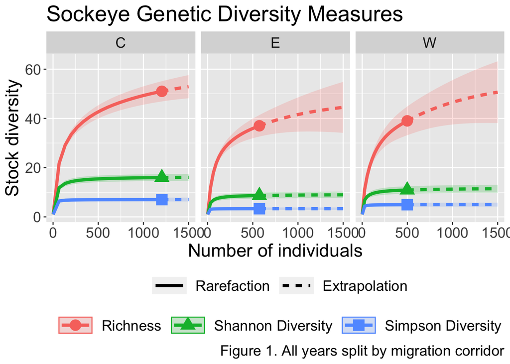

```r
di <- dna |>
  filter(region == "DI") |>
  mutate(year = lubridate::year(survey_date),
         yday = lubridate::yday(survey_date)) |>
  drop_na(stock_1, zone) %>%
  group_by(stock_1, zone) %>%
   summarize(n = n()) %>%
   spread(key = zone, value = n) %>%
   replace_na(list("E" = 0, "W" =  0, "C" =  0)) %>%
  as.data.frame()

rownames(di) <- di[,1]
di[,1] <- NULL

di_output <- iNEXT(di, q = c(0, 1, 2), datatype = "abundance", endpoint = 1500)

di_output[["DataInfo"]][["site"]] <- fct_relevel(di_output[["DataInfo"]][["Assemblage"]],
                                                 "W", "C", "E")

p7 <- ggiNEXT(di_output, type=1, facet.var = "Assemblage") +
  ggtitle("Sockeye Genetic Diversity Measures") +
  labs(caption = "Figure 1. All years split by migration corridor")

hill_labels(p7) +
  ylab("Stock diversity")
```

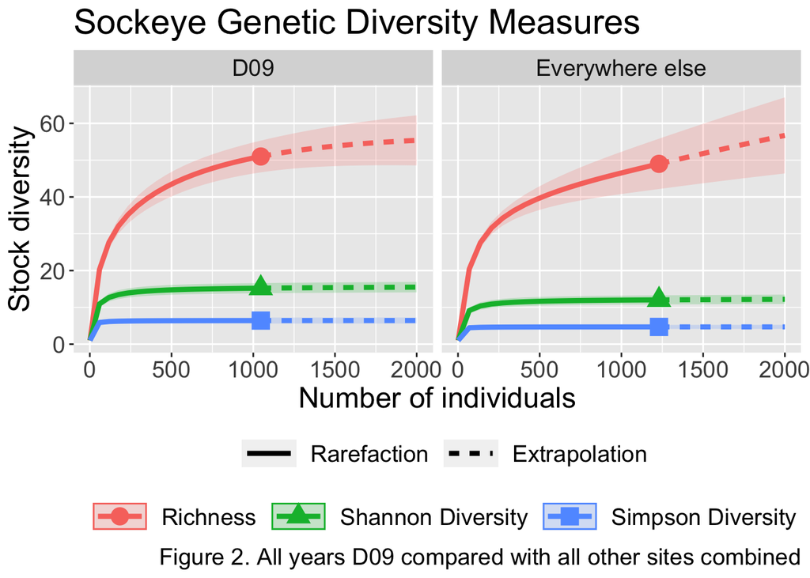

```r
d9_vs <- dna |>
  filter(region == "DI") |>
  mutate(year = lubridate::year(survey_date),
         yday = lubridate::yday(survey_date)) |>
  drop_na(stock_1, zone) %>%
  mutate(D09 = if_else(site == "D09", "D09", "Everywhere else")) |>
  group_by(stock_1, D09) |>
  summarize(n = n()) |>
    spread(key = D09, value = n) |>
    replace_na(list("D09" = 0, "Everywhere else" = 0)) |>
    as.data.frame()

rownames(d9_vs) <- d9_vs[,1]
d9_vs[,1] <- NULL

d9_output <- iNEXT(d9_vs, q = c(0, 1, 2), datatype = "abundance", endpoint = 2000)

d9_output[["DataInfo"]][["site"]] <- fct_relevel(d9_output[["DataInfo"]][["Assemblage"]],
                                                 "D09","Everywhere else")

p8 <- ggiNEXT(d9_output, type=1, facet.var = "Assemblage") +
  ggtitle("Sockeye Genetic Diversity Measures") +
  labs(caption = "Figure 2. All years D09 compared with all other sites combined")

hill_labels(p8) +
  ylab("Stock diversity")
```

# 2 Annual Samplling Diversity and Completeness

## 2.1 Diversity

Breaking out stock diversities by year you can see we are sampling different population structures across years that have different stock diversities (Figure 3).

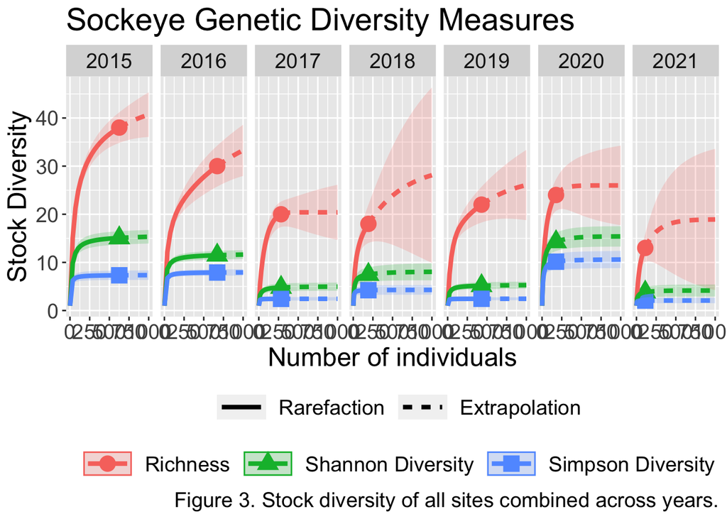

```r
all <- dna |>
  filter(region == "DI") |>
   mutate(year = lubridate::year(survey_date),
         yday = lubridate::yday(survey_date)) |>
  drop_na(stock_1) |>
  group_by(year, stock_1) |>
  summarize(n = n()) |>
    spread(key = year, value = n) |>
    replace_na(list("2015" = 0, "2016" = 0, "2017" = 0, "2018" = 0, "2019" = 0,
                    "2020" = 0, "2021" = 0)) |>
    as.data.frame()

rownames(all) <- all[,1]
all[,1] <- NULL

all_output <- iNEXT(all, q = c(0, 1, 2), datatype = "abundance", endpoint = 1000)

all_output[["DataInfo"]][["site"]] <- fct_relevel(all_output[["DataInfo"]][["Assemblage"]],
                                                 "2015","2016", "2017", "2018", "2019", "2020", "2021")

p13 <- ggiNEXT(all_output, type=1, facet.var = "Assemblage") +
  ggtitle("Sockeye Genetic Diversity Measures") +
  labs(caption = "Figure 3. Stock diversity of all sites combined across years.")
hill_labels(p13) +
  ylab("Stock Diversity")
```

This graph is kind of hard to read if you want to compare diversities for the same sample size. So, Table 1 gives expected species richness (qD) for a given sample size (m).

```r
annual_min_ss <-estimateD(all, datatype = "abundance", base = "size", q = 0) |>
  mutate(Assemblage = as.numeric(Assemblage))
knitr::kable(annual_min_ss, caption = "Table 1. Modelled species richness using a common sample size (which is twice the size of the smallest sample size")
```

Table 1. Modelled species richness using a common sample size (which is twice the size of the smallest sample size

| Assemblage | m | Method | Order.q | SC | qD | qD.LCL | qD.UCL |
| --- | --- | --- | --- | --- | --- | --- | --- |
| 2015 | 224 | Rarefaction | 0 | 0.9659453 | 30.93868 | 28.96400 | 32.91336 |
| 2016 | 224 | Rarefaction | 0 | 0.9740875 | 22.49571 | 20.81861 | 24.17281 |
| 2017 | 224 | Rarefaction | 0 | 0.9840408 | 19.33836 | 17.26301 | 21.41370 |
| 2018 | 224 | Extrapolation | 0 | 0.9757624 | 18.77694 | 14.13067 | 23.42322 |
| 2019 | 224 | Rarefaction | 0 | 0.9807764 | 18.97447 | 16.76823 | 21.18071 |
| 2020 | 224 | Extrapolation | 0 | 0.9867477 | 24.80268 | 22.17097 | 27.43440 |
| 2021 | 224 | Extrapolation | 0 | 0.9818458 | 15.90560 | 9.45831 | 22.35289 |

```r
sample_sizes <- dna |>
  group_by(year(survey_date))|>
  summarize(n_samples = n()) |>
  left_join(select(annual_min_ss, Assemblage, qD, qD.LCL, qD.UCL), by = c('year(survey_date)' = "Assemblage"))

knitr::kable(sample_sizes, caption = "Table 3. Number of genetic stock ID samples per year")
```

Table 3. Number of genetic stock ID samples per year

| year(survey_date) | n_samples | qD | qD.LCL | qD.UCL |
| --- | --- | --- | --- | --- |
| 2015 | 1241 | 30.93868 | 28.96400 | 32.91336 |
| 2016 | 1312 | 22.49571 | 20.81861 | 24.17281 |
| 2017 | 486 | 19.33836 | 17.26301 | 21.41370 |
| 2018 | 193 | 18.77694 | 14.13067 | 23.42322 |
| 2019 | 431 | 18.97447 | 16.76823 | 21.18071 |
| 2020 | 187 | 24.80268 | 22.17097 | 27.43440 |
| 2021 | 113 | 15.90560 | 9.45831 | 22.35289 |

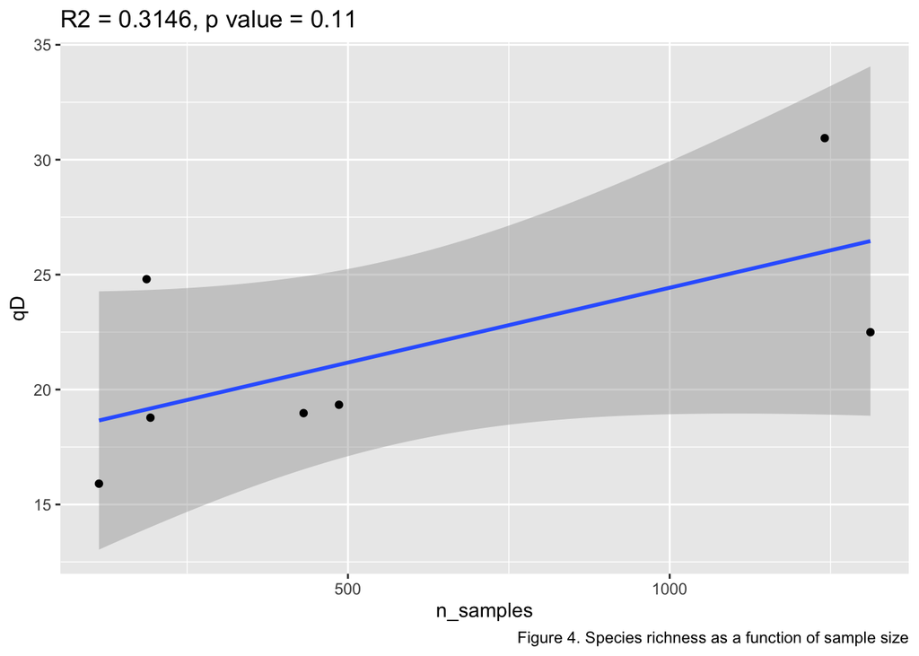

```r
ggplot(sample_sizes, aes(x = n_samples, y = qD)) +
  geom_smooth(method = lm) +
  geom_point() +
  ggtitle(label = "R2 = 0.3146, p value = 0.11") +
  labs(caption = "Figure 4. Species richness as a function of sample size")
```

```r
summary(lm(qD ~ n_samples, sample_sizes))
```

```
##
## Call:
## lm(formula = qD ~ n_samples, data = sample_sizes)
##
## Residuals:
##       1       2       3       4       5       6       7
##  4.9408 -3.9644 -1.7446 -0.3986 -1.7504  5.6662 -2.7491
##
## Coefficients:
##             Estimate Std. Error t value Pr(>|t|)
## (Intercept) 17.91910    2.46513   7.269  0.00077 ***
## n_samples    0.00651    0.00336   1.938  0.11041
## ---
## Signif. codes:  0 '***' 0.001 '**' 0.01 '*' 0.05 '.' 0.1 ' ' 1
##
## Residual standard error: 4.149 on 5 degrees of freedom
## Multiple R-squared:  0.4288, Adjusted R-squared:  0.3146
## F-statistic: 3.754 on 1 and 5 DF,  p-value: 0.1104
```

## 2.2 Sample coverage

Chao et al. “Coverage is defined as the proportion of the total number of individuals in an assemblage that belong to species represented in the sample. Turing and Good derived a simple coverage estimator (of the reference sample of size n) as one minus the proportion of singletons. A tiny percentage of coverage can contain an infinite number of rare species. The estimated complement of coverage is not an estimate of the number of unseen species, but rather it estimates the proportion of the total individuals in the assemblage that belong to undetected species.”

So what has our sample coverage been throughout the years? The sample coverage ranges between 0.965 to 0.994 (Figure 5.)

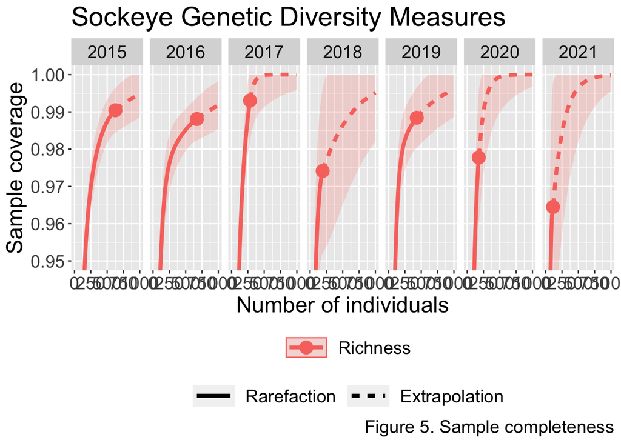

```r
p14 <- ggiNEXT(all_output, type=2, facet.var = "Assemblage") +
  ggtitle("Sockeye Genetic Diversity Measures") +
  labs(caption = "Figure 5. Sample completeness") +
  coord_cartesian(ylim = c(.95, 1))
hill_labels(p14)
```

So, what sample size would be required to attain a sample coverage of 0.99? See Table 4.

On average, looking at the whole year in aggregate (which is likely biased low and should be broken down by appropriate sample sizes per seine and per week) and calculating the median sample size required to reach 0.99 sample coverage we we end up at 509 samples per year. This is a broad look and certainly varies by sockeye cohort year.

```r
annual_closest_99 <- estimateD(all, datatype = "abundance", base = "coverage", level = 0.99, q = 0)

knitr::kable(annual_closest_99)
```

| Assemblage | m | Method | Order.q | SC | qD | qD.LCL | qD.UCL |
| --- | --- | --- | --- | --- | --- | --- | --- |
| 2015 | 600.3072 | Rarefaction | 0 | 0.99 | 37.74856 | 28.665026 | 46.83210 |
| 2016 | 827.1740 | Extrapolation | 0 | 0.99 | 31.70744 | 18.669718 | 44.74516 |
| 2017 | 260.1525 | Rarefaction | 0 | 0.99 | 19.80579 | 14.235943 | 25.37563 |
| 2018 | 649.3964 | Extrapolation | 0 | 0.99 | 25.62523 | 5.320117 | 45.93035 |
| 2019 | 509.8930 | Extrapolation | 0 | 0.99 | 22.85050 | 11.381440 | 34.31956 |
| 2020 | 249.0609 | Extrapolation | 0 | 0.99 | 25.09376 | 11.031974 | 39.15555 |
| 2021 | 323.5846 | Extrapolation | 0 | 0.99 | 17.27143 | 5.902814 | 28.64004 |

```r
annual_99_median <- as.numeric(median(annual_closest_99$m))
```

#Plan:

#Calculate number of samples needed to reach sampling coverage of .99 for each seine, week, and season.

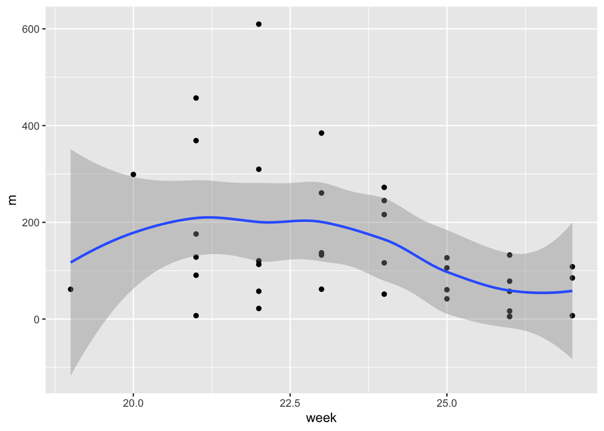

```r
weekly <- dna |>
  filter(region == "DI") |>
   mutate(year = lubridate::year(survey_date),
         yday = lubridate::yday(survey_date),
         week = week(survey_date),
         year_week = paste(year, week, sep = "-")) |>
  drop_na(stock_1) |>
  group_by(year_week, stock_1) |>
  summarize(n = n()) |>
    ungroup() |>
    spread(key = year_week, value = n, fill = 0) |>
    as.data.frame()

rownames(weekly) <- weekly[,1]
weekly[,1] <- NULL

weekly_output <- iNEXT(weekly, q = 0, datatype = "abundance", endpoint = 500)
weekly_output <- weekly_output[["iNextEst"]][["coverage_based"]]

# .99 coverage
weekly99_table <- estimateD(weekly, q = 0, datatype = "abundance", base = "coverage", level = 0.99) |>
  filter(SC == 0.99)

weekly_99_cleaned <- weekly99_table |>
  mutate(error = qD.UCL - qD.LCL) |>
  #filter(error < 20) |>
  mutate(week = as.numeric(substr(Assemblage, 6,7)))

weekly99_median <- as.numeric(median(weekly_99_cleaned$m))

ggplot(weekly_99_cleaned, aes(x = week, y = m)) +
  geom_point() +
  geom_smooth()
```

```r
beepr::beep(10)
```

# 3 Per seine

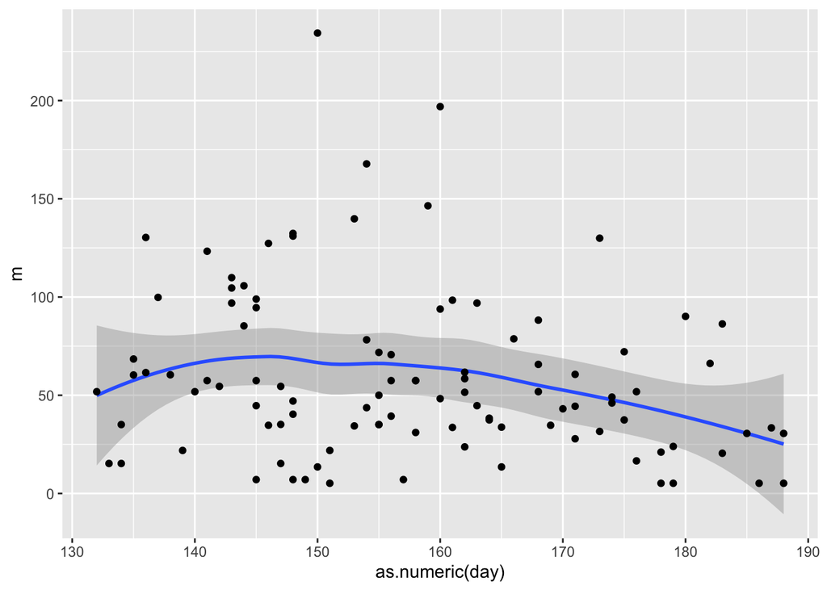

```r
daily <- dna |>
  filter(region == "DI") |>
   mutate(year = lubridate::year(survey_date),
         yday = lubridate::yday(survey_date),
         week = week(survey_date),
         year_day = paste(year, yday, sep = "-")) |>
  drop_na(stock_1) |>
  group_by(year_day, stock_1) |>
  summarize(n = n()) |>
    ungroup() |>
    spread(key = year_day, value = n, fill = 0) |>
    as.data.frame()


rownames(daily) <- daily[,1]
daily[,1] <- NULL

daily99 <- estimateD(daily, q = 0, datatype = "abundance", base = "coverage", level = 0.99) |>
  filter(SC == 0.99) |>
 mutate(day = as.numeric(substr(Assemblage, 6,8)))

daily_99 <- as.numeric(median(daily99$m))


ggplot(daily99, aes(x = as.numeric(day), y = m)) +
  stat_smooth(method = "loess" ) +
  geom_point()
```

```r
beepr::beep(3)
```

In summary:

D09 appears to be as diverse or more than other regions.

Median across the range of the migration period:

For each season we need a minimum of 509 samples

For each week we need 113 samples

For each day we need 50 samples on average.

I need to break it down by peak migration periods though